# Project Python Foundations: FoodHub Data Analysis

### **Question 8**: Which is the most popular cuisine on weekends? [1 mark]

```python
df_weekend = df[df['day_of_the_week'] == 'Weekend']
popular_cuisine = df_weekend['cuisine_type'].value_counts().head(1).reset_index()
popular_cuisine.columns = ['Cuisine Type','Orders received']
print(popular_cuisine.to_string(index=False))
```

```
Cuisine Type  Orders received
    American              415
```

#### Observations:

- The most popular cuisine on weekends are American cuisine based on the number of orders received. Would be good to understand the ratings this cuisine have obtained and why customers prefer them over others.

### **Question 9**: What percentage of the orders cost more than 20 dollars? [2 marks]

```python
#Get the total number of orders more than 20 and % of them across all the orders
df_greater_than_20 = df[df['cost_of_the_order']> 20]
print('The number of total orders that cost above 20 dollars is:', df_greater_than_20.shape[0])
percent_greater_than_20 = (df_greater_than_20.shape[0]/df.shape[0])*100
print("Percentage of orders above 20 dollars:", round(percent_greater_than_20, 2), '%')
```

```
The number of total orders that cost above 20 dollars is: 555
Percentage of orders above 20 dollars: 29.24 %
```

#### Observations:

- 29.24% of orders are above 20 dollars. Looks like approx 70% of the restaurants are offering food less than 20 dollars for people to use the online services.

### **Question 10**: What is the mean order delivery time? [1 mark]

```python
mean_order_delivery = df['delivery_time'].mean()
print("The mean order delivery time:",round(mean_order_delivery),"minutes") #minutes rounded off
```

```
The mean order delivery time: 24 minutes
```

#### Observations:

- The average delivery time is 24 minutes. It would be good to differntiate between weekdays and weekends to see the pattern.

### **Question 11:** The company has decided to give 20% discount vouchers to the top 3 most frequent customers. Find the IDs of these customers and the number of orders they placed. [1 mark]

```python
#Get the top 3 customers
top_3_customers = df['customer_id'].value_counts().head(3).reset_index()
top_3_customers.columns = ['Customer id', 'Orders placed']
print(top_3_customers.to_string(index=False))
```

```
 Customer id  Orders placed
       52832             13
       47440             10
       83287              9
```

#### Observations:

- The top 3 customers are with the customer id 52832, 47440, 83287

### **Question 12**: Perform a multivariate analysis to explore relationships between the important variables in the dataset. (It is a good idea to explore relations between numerical variables as well as relations between numerical and categorical variables) [10 marks]

#### Cuisine vs Cost of Order :

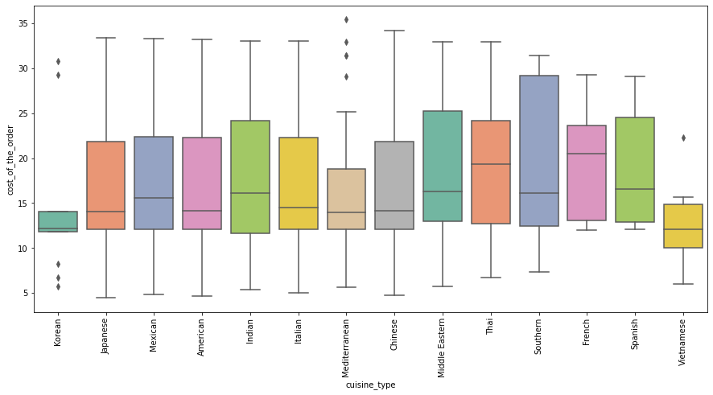

```python
# Relationship between cost of the order and cuisine type
plt.figure(figsize=(15,7))
sns.boxplot(x = "cuisine_type", y = "cost_of_the_order", data = df, palette = 'Set2')
plt.xticks(rotation = 90)
plt.show()
```

### Cuisine vs Food Preparation Time :

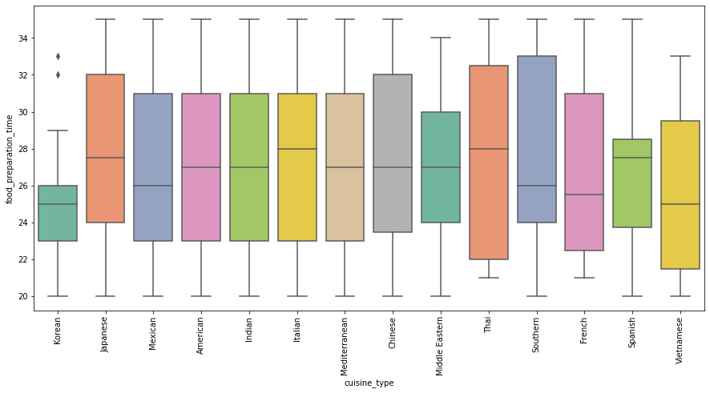

```python
# Relationship between Cuisine and food preparation time
plt.figure(figsize=(15,7))
sns.boxplot(x = "cuisine_type", y = "food_preparation_time", data = df, palette = 'Set2')
plt.xticks(rotation = 90)
plt.show()
```

### Day of the week vs Delivery Time

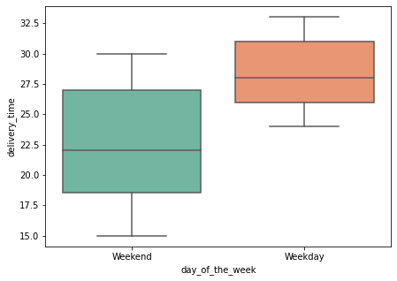

```python
# Relationship between day of the week and delivery time
plt.figure(figsize=(7,5))
sns.boxplot(x = "day_of_the_week", y = "delivery_time", data = df, palette = 'Set2')
plt.show()
```

```python
df.groupby(['restaurant_name'])['cost_of_the_order'].sum().sort_values(ascending = False).head(5)
```

```
restaurant_name
Shake Shack                  3579.53
The Meatball Shop            2145.21
Blue Ribbon Sushi            1903.95
Blue Ribbon Fried Chicken    1662.29
Parm                         1112.76
Name: cost_of_the_order, dtype: float64
```

```python
df.groupby(['cuisine_type'])['order_id'].count().sort_values(ascending = False).head(5)
```

```
cuisine_type
American    584
Japanese    470
Italian     298
Chinese     215
Mexican      77
Name: order_id, dtype: int64
```

### Rating vs Delivery Time

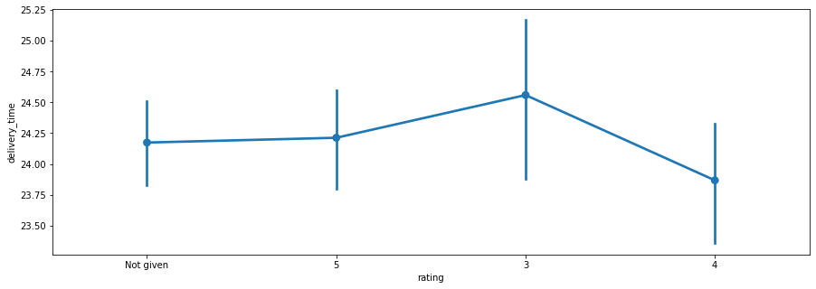

```python
# Relationship between rating and delivery time
plt.figure(figsize=(15, 5))
sns.pointplot(x = 'rating', y = 'delivery_time', data = df)
plt.show()
```

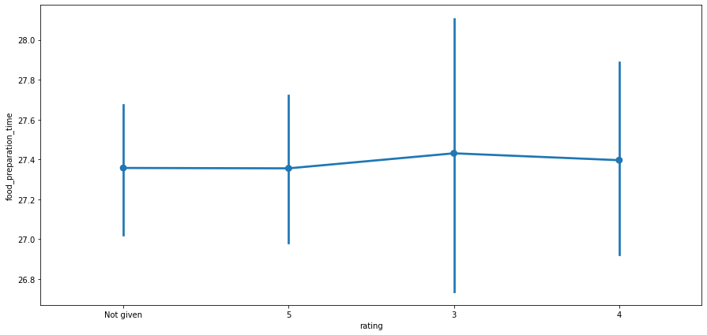

```python
# Relationship between rating and food preparation time
plt.figure(figsize=(15, 7))
sns.pointplot(x='rating', y='food_preparation_time', data=df)  ## Complete the code to visualize the relationship between rating and food preparation time using pointplot
plt.show()
```

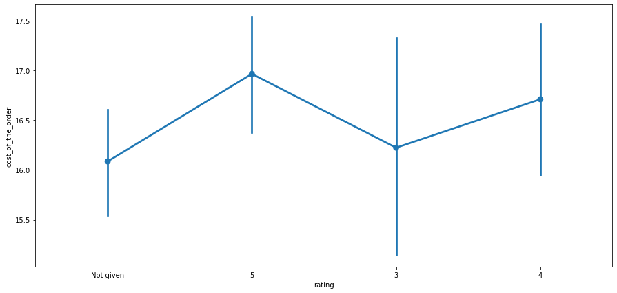

```python
# Relationship between rating and cost of the order
plt.figure(figsize=(15, 7))
sns.pointplot(x='rating', y='cost_of_the_order', data=df)  ## Complete the code to visualize the relationship between rating and cost of the order using pointplot
plt.show()
```

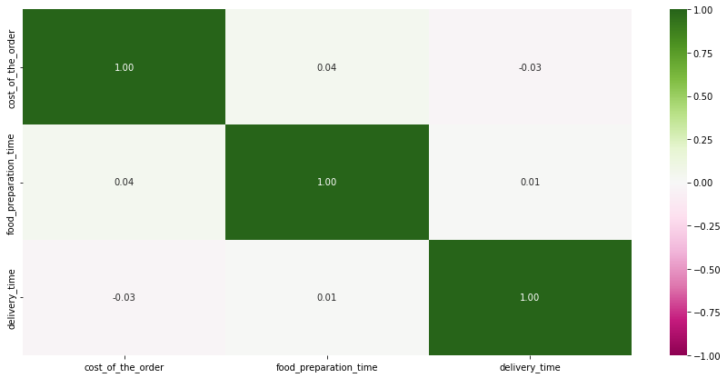

```python
#correlation between cost of the order, food preparation time and delivery time
col_list = ['cost_of_the_order', 'food_preparation_time', 'delivery_time']
plt.figure(figsize=(15, 7))
sns.heatmap(df[col_list].corr(), annot=True, vmin=-1, vmax=1, fmt=".2f", cmap="PiYG")
plt.show()
```

### **Question 13:** The company wants to provide a promotional offer in the advertisement of the restaurants. The condition to get the offer is that the restaurants must have a rating count of more than 50 and the average rating should be greater than 4. Find the restaurants fulfilling the criteria to get the promotional offer. [3 marks]

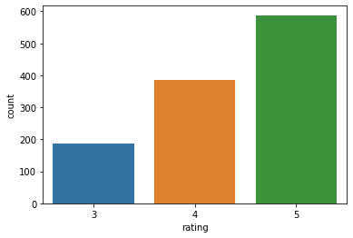

```python
df_rated = df[df['rating'] != 'Not given'].copy() #take a copy of the dataframe and assign to a new dataFrame

df_rated['rating'] = df_rated['rating'].astype('int') #convert the dataType from object to int64

sns.countplot(data=df_rated, x ='rating')
plt.show()
```

```python
df_rated_count = df_rated.groupby(['restaurant_name'])['rating'].count().sort_values(ascending = False).reset_index()
print(df_rated_count[df_rated_count['rating'] >=4].head())
```

```
             restaurant_name  rating
0                Shake Shack     133
1          The Meatball Shop      84
2          Blue Ribbon Sushi      73
3  Blue Ribbon Fried Chicken      64
4           RedFarm Broadway      41
```

### **Question 14:** The company charges the restaurant 25% on the orders having cost greater than 20 dollars and 15% on the orders having cost greater than 5 dollars. Find the net revenue generated by the company across all orders. [3 marks]

```python
#Function to define the above requirement
def compute_rev(x):
    if x > 20:
        return x*0.25
    elif x > 5:
        return x*0.15
    else:
        return x*0

df['Revenue'] = df['cost_of_the_order'].apply(compute_rev)

total_rev = df['Revenue'].sum()
print('The net revenue is around', round(total_rev, 2), 'dollars')
```

```
The net revenue is around 6166.3 dollars
```

#### Observations:

- The net revenue generated by the company is 6166.3 dollars.

### **Question 15:** The company wants to analyze the total time required to deliver the food. What percentage of orders take more than 60 minutes to get delivered from the time the order is placed? (The food has to be prepared and then delivered.) [2 marks]

```python
df['total_time'] = df['food_preparation_time'] + df['delivery_time']

percent_of_order = round(len(df[df['total_time'] > 60])/ len(df)*100,1)

print('Percentage of orders take more than 60 minutes to deliver:', percent_of_order,'%')
```

```
Percentage of orders take more than 60 minutes to deliver: 10.5 %
```

#### Observations:

- Approx 10.5 % customers orders take more than 60 minutes to deliver. This will have a negative impact on the rating.

### **Question 16:** The company wants to analyze the delivery time of the orders on weekdays and weekends. How does the mean delivery time vary during weekdays and weekends? [2 marks]

```python
print('The mean delivery time on weekdays is around',
      round(df[df['day_of_the_week'] == 'Weekday']['delivery_time'].mean()),
     'minutes')

print('The mean delivery time on weekends is around',
      round(df[df['day_of_the_week'] == 'Weekend']['delivery_time'].mean()),
      'minutues')
```

```
The mean delivery time on weekdays is around 28 minutes
The mean delivery time on weekends is around 22 minutues
```

#### Observations:

- compared to the weekends, the weekday delivery takes more than 6 minutes. This may be due to the busy hours the order may be placed. The hourly data analysis would help to confirm this.